# Presentation Code | Swire Coca-Cola Capstone Project

IS 6813-001, Spring 2025 | Group 3

Authors

Adam Bushman

Georgia Christodoulou

Tyler Swanson

Zac Mendenhall

Published

April 7, 2025

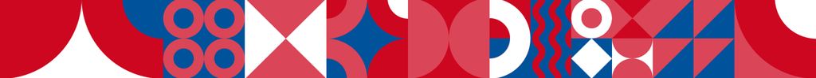

```r
library('tidyverse')
setwd("/home/adam-bushman/All Projects/delivery-standardization-group")

swire_segmentation <- readRDS('data/derived/swire_customer_segments.Rds')
```

## Summarizing Segments

The below will calculate the number of customers for each group and key summary metrics. These data are included in slides #15-#16.

```r
swire_segmentation |>
    group_by(segment) |>
    summarise(
        n = n(),  # Number of customers in each segment
        total_volume = sum(annual_total),  # Total volume across all customers in the segment
        avg_annual_transactions = median((order_transactions_2023 + order_transactions_2024) / 2),  # Median annual order count
        avg_annual_volume = median((ordered_total_2023 + ordered_total_2024) / 2),  # Median annual ordered volume
        avg_transaction = median(avg_transaction_amt),  # Median transaction size
        avg_neighbor_annual_volume = median((neighbor_avg_ordered_total_2023 + neighbor_avg_ordered_total_2024) / 2),  # Median neighbor volume
    ) |>
    ungroup() |>
    mutate(
        n_perc = n / sum(n),  # Share of customers in this segment
        vol_perc = total_volume / sum(total_volume)  # Share of total volume from this segment
    ) |>
    select(
        segment, n, n_perc, total_volume, vol_perc,
        avg_annual_transactions, avg_annual_volume, avg_transaction, avg_neighbor_annual_volume
    )
```

```
# A tibble: 2 × 9
  segment         n n_perc total_volume vol_perc avg_annual_transactions
  <chr>       <int>  <dbl>        <dbl>    <dbl>                   <dbl>
1 RED TRUCK   17994  0.593    16866615.    0.879                    12.5
2 WHITE TRUCK 12328  0.407     2332288.    0.121                    11
# ℹ 3 more variables: avg_annual_volume <dbl>, avg_transaction <dbl>,
#   avg_neighbor_annual_volume <dbl>
```

## Estimate Business Potential

Part of understanding the potential of our solution over that of the incumbent strategy hinges on an estimate for 2025 (theoretically, what hasn’t happened yet). We’ll derive that in a fairly nuanced fashion, by using % increase from 2023 to 2024 by `trade_channel`.

### Get a 2025 gallons + cases estimate

```r
swire_2025_est <-
    swire_segmentation |>
    mutate(
        tenure_slice = cut(customer_tenure_yrs, 4)  # Bin tenure into 4 equal-width ranges
    ) |>
    group_by(trade_channel) |>
    mutate(
        growth_23_24 = sum(ordered_total_2024) / sum(ordered_total_2023)  # Channel-level growth rate
    ) |>
    ungroup() |>
    mutate(
        ovr_growth_23_24 = sum(ordered_total_2024) / sum(ordered_total_2023),  # Overall system-wide growth
        assumed_growth_rate = ifelse(growth_23_24 == Inf, ovr_growth_23_24, growth_23_24)  # Handle divide-by-zero cases
    ) |>
    mutate(
        ordered_total_2025_est = ifelse(
            ordered_total_2024 > 0,
            assumed_growth_rate * ordered_total_2024,
            0  # Only project growth if non-zero 2024 volume
        ),
        delivered_total_2025_est = ifelse(
            delivered_total_2024 > 0,
            assumed_growth_rate * delivered_total_2024,
            0
        ),
        delivered_cost_2025_est = ifelse(
            delivered_total_2024 > 0,
            delivered_total_2025_est * (delivered_cases_cost_2024 + delivered_gallons_cost_2024) / delivered_total_2024,
            0  # Carry forward cost per unit to estimate 2025 costs
        ),
        across(
            ordered_total_2025_est:delivered_total_2025_est,
            ~round(., 1)  # Round 2025 volume estimates for cleaner reporting
        )
    )
```

It’s important to confirm the increase.

```r
# Order total increase %
sum(swire_2025_est$ordered_total_2025_est) / sum(swire_2025_est$ordered_total_2024)
```

```
[1] 1.063002
```

```r
# Delivered total increase %
sum(swire_2025_est$delivered_total_2025_est) / sum(swire_2025_est$delivered_total_2024)
```

```
[1] 1.063249
```

```r
# Delivered cost increase %
sum(swire_2025_est$delivered_cost_2025_est) / sum(swire_2025_est$delivered_cases_cost_2024 + swire_2025_est$delivered_gallons_cost_2024)
```

```
[1] 1.068157
```

### Business Potential Perspectives

With that estimate, it’s time to calculate comparison values we’ll use in the presentation.

#### Future Opportunity

This is included in slide #20.

```r
swire_2025_est |>
  mutate(
    order_over_400 = ordered_total_2024 >= 400,  # Flag customers with 2024 volume ≥ 400
    strategy = case_when(
        segment == 'WHITE TRUCK' & order_over_400 ~ 'Incumbent',  # Large customers under current strategy
        segment == 'RED TRUCK' & !order_over_400 ~ 'Proposed'  # Small customers targeted under new strategy
    )
  ) |>
  filter(!is.na(strategy)) |>  # Keep only rows relevant to strategy analysis
  group_by(strategy) |>
  summarise(
    opportunity_2025 = sum(delivered_cost_2025_est)  # Total projected 2025 delivery cost by strategy group
  )
```

```
# A tibble: 2 × 2
  strategy  opportunity_2025
  <chr>                <dbl>
1 Incumbent         2988845.
2 Proposed          7638911.
```

#### Opportunity Cost

This perspective measures the estimated 2025 gallons + cases that were “lost” or rerouted to the WHITE TRUCK program across each strategy. Swire would prefer the strategy with the lower value since opportunity ceded to the WHITE TRUCK program is less optimal.

This is included in slide #38.

```r
swire_2025_est |>
  mutate(
    order_over_400 = ordered_total_2024 >= 400  # Flag customers with 2024 volume ≥ 400
  ) |>
  summarise(
    incumbent = sum(ifelse(!order_over_400, ordered_total_2025_est, 0)),  # Projected 2025 volume from sub-400 customers
    proposed = sum(ifelse(segment == 'WHITE TRUCK', ordered_total_2025_est, 0))  # Projected 2025 volume from WHITE TRUCK segment
  ) |>
  select(incumbent, proposed)
```

```
# A tibble: 1 × 2
  incumbent proposed
      <dbl>    <dbl>
1  2937816. 2395399.
```

### Delivery Costs

This perspective measures the estimated 2025 cost of delivery gallons + cases to the those that were rerouted to the WHITE TRUCK program across each strategy. Swire would prefer the strategy with the higher value since delivery costs avoided are dollars saved by Swire.

This is included in slide #39.

```r
swire_2025_est |>
  mutate(
    order_over_400 = ordered_total_2024 >= 400  # Flag customers with 2024 volume ≥ 400
  ) |>
  summarise(
    incumbent = sum(ifelse(!order_over_400, delivered_cost_2025_est, 0)),  # Total 2025 cost for sub-400 volume customers
    proposed = sum(ifelse(segment == 'WHITE TRUCK', delivered_cost_2025_est, 0))  # Total 2025 cost for proposed WHITE TRUCK segment
  ) |>
  select(incumbent, proposed)
```

```
# A tibble: 1 × 2
  incumbent proposed
      <dbl>    <dbl>
1 13672146. 9022079.
```

### Labor hours servicing account

This perspective measures the estimated labor hours of servicing WHITE TRUCK accounts in 2025 that would be recouped. Swire would prefer the strategy with the higher value since labor hours not spent on WHITE TRUCK customers are instead leveraged for the RED TRUCK program.

This is included in slide #40.

Have to create some assumptions. Worked with ChatGPT (4o model) using the following prompt:

> I’m working on a project where I want to estimate the number of labor hours a company supports a client account across sales and customer service departments annually. I need to have a heuristic of labor hours for each customer. Give me some industry benchmarks for the food and beverage wholesaler industry (i.e. a Pepsi selling to a restaurant) for the range of labor hours spent annually for sales and customer service needs of the account.

This is the table of results:

| **Customer Tier** | **Description** | **Sales Labor (hrs/year)** | **Customer Service Labor (hrs/year)** | **Total Labor (hrs/year)** |
| --- | --- | --- | --- | --- |
| **Enterprise** | National/multi-location chains (e.g. Applebee’s) | 40–80 | 20–40 | **60–120** |
| **Mid-Market** | Large independents or regional chains | 15–30 | 10–20 | **25–50** |
| **SMB / Long Tail** | Small restaurants, single location | 2–10 | 2–10 | **4–20** |

So let’s generate a look-up table. We’ll go with the low estimate here, just to be safe.

```r
lookup <- tibble(
  tier = c("Enterprise", "Mid-market", "SMB"),  # Customer tiers
  sales_labor = c(40, 15, 2),  # Estimated sales labor hours per customer
  cx_labor = c(20, 10, 2)  # Estimated customer experience labor hours per customer
) |>
  mutate(
    tot_labor = sales_labor + cx_labor  # Total labor per customer = sales + CX
  )
```

Now we need to derive a tier for each of our the customers. Let’s just use percentiles and primary group count. Let’s get a sense for the distribution:

```r
quantile(swire_2025_est$annual_total, c(0, 0.25, 0.5, 0.75, 0.95, 0.99))
```

```
      0%      25%      50%      75%      95%      99%
   0.000   56.500  150.750  407.500 1841.623 7116.260
```

```r
quantile(swire_2025_est$primary_group_customers_2024, c(0, 0.25, 0.5, 0.75, 0.95, 0.99))
```

```
 0% 25% 50% 75% 95% 99%
  0   0   0  23 557 668
```

```r
swire_2025_est_tiers <-
  swire_2025_est |>
  mutate(
    tier = case_when(
      # SMB
      # These customers have no franchises AND do less than the 75%tile annual volume
      primary_group_customers_2024 == 0 & annual_total <= 407 ~ "SMB"

      # Mid-market
      # These customers have either less than 75%tile franchise count OR annual volume is less than 95%tile
      , primary_group_customers_2024 <= 23 | annual_total <= 1841  ~ "Mid-market"

      # Mid-market
      # These customers have greater than 75%tile franchise count AND annual volume is greater than 95%tile
      , primary_group_customers_2024 > 23 & annual_total > 1841 ~ "Enterprise"
      , TRUE ~ "X"
    ),
    tier = factor(tier, levels = c("SMB", "Mid-market", "Enterprise"))
  )

swire_2025_est_tiers
```

```
# A tibble: 30,322 × 76
   customer_number primary_group_number cold_drink_channel frequent_order_type
   <chr>           <chr>                <fct>              <fct>
 1 500245678       <NA>                 EVENT              SALES REP
 2 500245685       <NA>                 DINING             OTHER
 3 500245686       8333                 GOODS              CALL CENTER
 4 500245687       <NA>                 EVENT              OTHER
 5 500245689       <NA>                 DINING             OTHER
 6 500245690       2272                 DINING             SALES REP
 7 500245695       <NA>                 WELLNESS           OTHER
 8 500245698       8940                 DINING             OTHER
 9 500245701       <NA>                 DINING             SALES REP
10 500245704       2487                 DINING             OTHER
# ℹ 30,312 more rows
# ℹ 72 more variables: trade_channel <fct>, sub_trade_channel <fct>,
#   local_market_partner <int>, co2_customer <int>, state <fct>, lat <dbl>,
#   lon <dbl>, primary_group_customers_2023 <dbl>,
#   primary_group_customers_2024 <dbl>, return_frequency_2023 <dbl>,
#   return_frequency_2024 <dbl>, year_2023 <int>, year_2024 <int>,
#   order_transactions_2023 <dbl>, order_transactions_2024 <dbl>, …
```

These seem like some pretty decent distributions. Let’s go with it. We now just join our lookup table and make a calculation:

```r
swire_tiers <-
  swire_2025_est_tiers |>
  mutate(
    plus_400 = annual_total >= 400  # Flag customers with annual volume ≥ 400
  ) |>
  inner_join(lookup) |>  # Add labor tier information from lookup table
  group_by(segment, plus_400, tot_labor, tier) |>
  summarise(
    n = n()  # Count number of customers in each group
  ) |>
  ungroup() |>
  mutate(
    assumed_labor_hrs = tot_labor * n  # Total estimated labor hours = labor per customer * number of customers
  )
```

```r
swire_tiers |>
  summarise(
    incumbent = sum(ifelse(!plus_400, assumed_labor_hrs, 0)),  # Total labor hours for customers under 400 volume
    proposed = sum(ifelse(segment == 'WHITE TRUCK', assumed_labor_hrs, 0))  # Total labor hours for proposed WHITE TRUCK segment
  ) |>
  select(incumbent, proposed)
```

```
# A tibble: 1 × 2
  incumbent proposed
      <dbl>    <dbl>
1    248741   161011
```

### Red Truck Program Efficiency

This perspective estimates the efficiency of the RED TRUCK program, by calculating the total 2025 gallons + cases orderd for every $100 of delivery costs. Swire would prefer the strategy with the higher value since higher order volume for the same amount of delivery costs is indicative of higher margins.

This is included in slide #21.

```r
swire_2025_est |>
  mutate(
    order_over_400 = ordered_total_2024 >= 400  # Flag customers with 2024 volume ≥ 400
  ) |>
  summarise(
    incumbent_vol = sum(ifelse(order_over_400, ordered_total_2025_est, 0)),  # Projected volume from existing large customers
    proposed_vol = sum(ifelse(segment == 'RED TRUCK', ordered_total_2025_est, 0)),  # Projected volume from targeted segment
    incumbent_cost = sum(ifelse(order_over_400, delivered_cost_2025_est, 0)),  # Projected cost from existing large customers
    proposed_cost = sum(ifelse(segment == 'RED TRUCK', delivered_cost_2025_est, 0))  # Projected cost from targeted segment
  ) |>
  mutate(
    incumbent = (incumbent_vol / incumbent_cost) * 100,  # Volume per $100 of cost for incumbent customers
    proposed = (proposed_vol / proposed_cost) * 100  # Volume per $100 of cost for RED TRUCK segment
  ) |>
  select(incumbent, proposed)
```

```
# A tibble: 1 × 2
  incumbent proposed
      <dbl>    <dbl>
1      75.7     65.2
```

## Miscellaneous Vizualizations

```r
# Branding colors
swire_colors <- list(
  "red" = "#cd0720",
  "blue" = "#005398",
  "gray" = "#f2f2f2"
)

# Custom {ggplot2} theme
theme_swire <- function() {
    theme(
    plot.title.position = "plot",

    plot.background = element_rect(fill = "white", color = NA),
    panel.background = element_rect(fill = swire_colors$gray, color = NA),

    plot.title = element_text(color = swire_colors$red, face = "bold", family = "Poppins"),
    plot.subtitle = element_text(face = "italic", family = "Poppins"),
    axis.title = element_text(face = "bold", family = "Poppins"),
    axis.text = element_text(family = "Poppins"),

    strip.background = element_rect(fill = swire_colors$blue, color = NA),
    strip.text = element_text(color = "white", face = "bold")
  )
}
```

This visualization compares measures of volume against efficiency by segment for our proposal. This visualization is seen on slides #15 and #37.

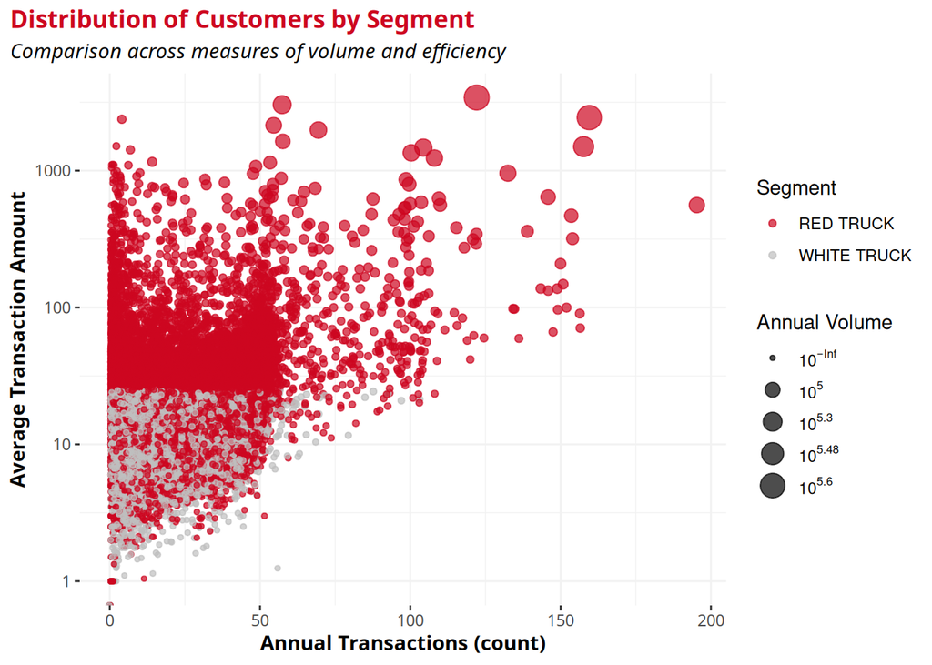

```r
ggplot(
  swire_2025_est,
  aes(
    x = (order_transactions_2023 + order_transactions_2024) / 2,  # Average annual transaction count
    y = avg_transaction_amt,  # Efficiency: average amount per transaction
    color = segment,  # Segment used for color coding
    size = annual_total  # Total annual volume used for point size
  )
) +
  geom_jitter(
    alpha = 0.7  # Add jitter for visibility and transparency to reduce overplotting
  ) +
  scale_color_manual(
    values = c(swire_colors$red, "gray")  # Manual segment color assignment
  ) +
  scale_y_log10() +  # Log scale for better distribution of y-axis
  scale_size_continuous(
    labels = scales::label_log()  # Label sizes using log scale
  ) +
  labs(
    title = "Distribution of Customers by Segment",
    subtitle = "Comparison across measures of volume and efficiency",
    x = "Annual Transactions (count)",
    y = "Average Transaction Amount",
    size = "Annual Volume",
    color = "Segment"
  ) +
  theme_swire() +
  theme(
    panel.background = element_rect(fill = "white", color = NA),  # Clean white background
    panel.grid = element_line(color = swire_colors$gray, linewidth = 0.5)  # Subtle gray gridlines
  )
```

This visualization seeks to describe how customers who met the incumbent threshold did so in largely inefficient manners. This visualization is seen on slide #28.

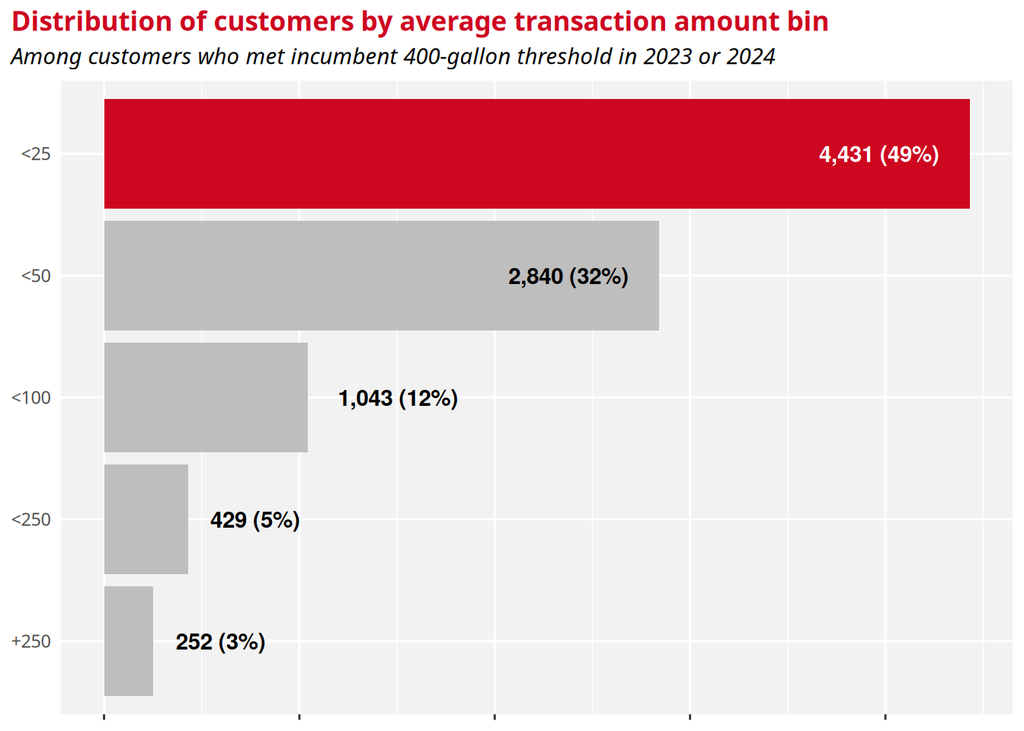

```r
swire_segmentation |>
    mutate(
        avg_tx_bin = case_when(
            avg_transaction_amt < 25 ~ "<25",
            avg_transaction_amt < 50 ~ "<50",
            avg_transaction_amt < 100 ~ "<100",
            avg_transaction_amt < 250 ~ "<250",
            TRUE ~ "+250"
        ),
        avg_tx_bin = factor(avg_tx_bin, levels = c("<25", "<50", "<100", "<250", "+250"))  # Set custom factor level order
    ) |>
    filter(
        ordered_total_2023 >= 400 | ordered_total_2024 >= 400  # Include only customers who meet volume threshold in either year
    ) |>
    group_by(avg_tx_bin, .drop = "groups") |>
    summarise(
        n = n()  # Count customers in each bin
    ) |>
    mutate(
        perc = n / sum(n)  # Calculate percent share per bin
    ) |>
    ggplot(
        aes(
            x = n,
            y = forcats::fct_rev(avg_tx_bin),  # Flip bin order for plotting
            label = paste0(
                scales::label_comma()(n), " (",
                scales::label_percent(accuracy = 1)(perc), ")"  # Display count and percent
            )
        )
    ) +
    geom_col(
        aes(fill = ifelse(avg_tx_bin == "<25", swire_colors$red, "gray"))  # Highlight "<25" in red
    ) +
    geom_text(
        aes(
            hjust = ifelse(perc < 0.2, -0.25, 1.25),  # Push label outside for small bars
            color = ifelse(avg_tx_bin == "<25", "white", "black")  # Match text color to background
        ),
        fontface = "bold"
    ) +
    scale_fill_identity() +
    scale_color_identity() +
    labs(
        title = "Distribution of customers by average transaction amount bin",
        subtitle = "Among customers who met incumbent 400-gallon threshold in 2023 or 2024"
    ) +
    theme_swire() +
    theme(
        axis.title = element_blank(),
        axis.text.x = element_blank(),
        axis.ticks.y = element_blank()
    )
```